# Estudios de Informática, Multimedia y Telecomunicaciones

# Minería de datos: PRA2 - Modelado de un juego de datos

Autor: Alberto Sánchez Mazarro

Junio 2020

# 1 Introducción

## 1.1 Presentación

Esta práctica cubre de forma transversal la asignatura.

Las Prácticas 1 y 2 de la asignatura se plantean de una forma conjunta de modo que la Práctica 2 será continuación de la 1.

El objetivo global de las dos prácticas consiste en seleccionar uno o varios juegos de datos, realizar las tareas de preparación y análisis exploratorio con el objetivo de disponer de datos listos para aplicar algoritmos de clustering, asociación y clasificación.

## 1.2 Competencias

Las competencias que se trabajan en esta prueba son:

- Uso y aplicación de las TIC en el ámbito académico y profesional.
- Capacidad para innovar y generar nuevas ideas.
- Capacidad para evaluar soluciones tecnológicas y elaborar propuestas de proyectos teniendo en cuenta los recursos, las alternativas disponibles y las condiciones de mercado.
- Conocer las tecnologías de comunicaciones actuales y emergentes así como saberlas aplicar convenientemente para diseñar y desarrollar soluciones basadas en sistemas y tecnologías de la información.
- Aplicación de las técnicas específicas de ingeniería del software en las diferentes etapas del ciclo de vida de un proyecto.
- Capacidad para aplicar las técnicas específicas de tratamiento, almacenamiento y administración de datos.
- Capacidad para proponer y evaluar diferentes alternativas tecnológicas para resolver un problema concreto.

## 1.3 Objetivos

La correcta asimilación de todos los aspectos trabajados durante el semestre.  
En esta práctica abordamos un caso real de minería de datos donde tenemos que poner en juego todos los conceptos trabajados. Hay que trabajar todo el ciclo de vida del proyecto. Desde el objetivo del proyecto hasta la implementación del conocimiento encontrado pasando por la preparación, limpieza de los datos, conocimiento de los datos, generación del modelo, interpretación y evaluación.

## 1.4 Descripción de la PEC a realizar

## 1.5 Recursos Básicos

Material docente proporcionado por la UOC.

## 1.6 Criterios de valoración

**Ejercicios prácticos**

Para todas las PEC es necesario documentar en cada apartado del ejercicio práctico que se ha hecho y como se ha hecho.

## 1.7 Formato y fecha de entrega

El formato de entrega es: usernameestudiante-PECn.html/doc/docx/odt/pdf  
Fecha de entrega: 15/01/2020  
Se debe entregar la PEC en el buzón de entregas del aula

## 1.8 Nota: Propiedad intelectual

> A menudo es inevitable, al producir una obra multimedia, hacer uso de recursos creados por terceras personas. Es por lo tanto comprensible hacerlo en el marco de una práctica de los estudios de Informática, Multimedia y Telecomunicación de la UOC, siempre y cuando esto se documente claramente y no suponga plagio en la práctica.

> Por lo tanto, al presentar una práctica que haga uso de recursos ajenos, se debe presentar junto con ella un documento en que se detallen todos ellos, especificando el nombre de cada recurso, su autor, el lugar donde se obtuvo y su estatus legal: si la obra esta protegida por el copyright o se acoge a alguna otra licencia de uso (Creative Commons, licencia GNU, GPL …). El estudiante deberá asegurarse de que la licencia no impide específicamente su uso en el marco de la práctica. En caso de no encontrar la información correspondiente tendrá que asumir que la obra esta protegida por copyright.

> Deberéis, además, adjuntar los ficheros originales cuando las obras utilizadas sean digitales, y su código fuente si corresponde.

# 2 Enunciado

Como continuación del estudio iniciado en la práctica 1, procedemos en esta práctica 2 a aplicar modelos analíticos sobe el juego de datos seleccionado y preparado en la práctica anterior.

De este modo se pide al estudiante que complete los siguientes pasos:

1. Aplicar un modelo de generación de reglas a partir de **árboles de decisión**.
2. Aplicar un modelo **no supervisado** y basado en el concepto de **distancia**, sobre el juego de datos.
3. Aplica de nuevo el modelo anterior, pero usando una **métrica distinta** y compara los resultados.
4. Aplicar un **modelo supervisado** sobre el juego de datos **sin** haber aplicado previamente **PCA/SVD**.
5. Aplicar un **modelo supervisado** sobre el juego de datos habiendo aplicado previamente **PCA/SVD**.
6. ¿Ha habido mejora en capacidad predictiva, tras aplicar PCA/SVD? ¿A qué crees que es debido?.

# 3 Rúbrica

# 4 Desarrollo de la práctica

Se va a intentar desarrollar la práctica sobre el mismo dataset que se ejecutó la PRA1. Si observamos dificultades, tal y como se comentó que podía suceder al revisar la PRA1 se tratará de buscar otro dataset.

Refrescando, el dataset mide el volumen de tráfico entre Minneapolis y Saint Paul a cada hora del día durante 6 años. Se incluye en el conjunto de datos información referente a las condiciones meteorológicas del momento de la medición.

Los datos del dataset sin manipular son:

holiday - Indicador de si es período vacacional o no

temp - temperatura en Kelvin

rain_1h - mm de lluvia en la hora

snow_1h - mm de nieve en la hora

clouds_all - porcentaje de nubosidad en ela hora

weather_main - breve descripción categórica del tiempo

weather_description - descripción categórica algo más detallada

date_time - hora de la medición

traffic_volume - cantidad de vehículos circulando hacia el oeste durante esa hora

**Reglas de asociación**

Para el primer punto del ejercicio vamos a intentar encontrar reglas de asociación entre los atributos. Para ello, vamos categorizar los atributos:

Vamos a empezar por volver a cargar el dataset:

```r
#Cargamos el dataset y hacemos una primera inspección del mismo
library(weathermetrics)
library(cluster)
library(dplyr)
library(class)
library(ggplot2)
library(rpart)
library(rpart.plot)
library(caret)
library(sqldf)

datos <- read.csv('/Users/Alberto/UOC/Minería/PRA2/Metro_Interstate_Traffic_Volume.csv',stringsAsFactors = FALSE, header = TRUE)

datosCopia<-datos

summary(datos)
```

```
##    holiday               temp          rain_1h            snow_1h
##  Length:48204       Min.   :  0.0   Min.   :   0.000   Min.   :0.0000000
##  Class :character   1st Qu.:272.2   1st Qu.:   0.000   1st Qu.:0.0000000
##  Mode  :character   Median :282.4   Median :   0.000   Median :0.0000000
##                     Mean   :281.2   Mean   :   0.334   Mean   :0.0002224
##                     3rd Qu.:291.8   3rd Qu.:   0.000   3rd Qu.:0.0000000
##                     Max.   :310.1   Max.   :9831.300   Max.   :0.5100000
##    clouds_all     weather_main       weather_description  date_time
##  Min.   :  0.00   Length:48204       Length:48204        Length:48204
##  1st Qu.:  1.00   Class :character   Class :character    Class :character
##  Median : 64.00   Mode  :character   Mode  :character    Mode  :character
##  Mean   : 49.36
##  3rd Qu.: 90.00
##  Max.   :100.00
##  traffic_volume
##  Min.   :   0
##  1st Qu.:1193
##  Median :3380
##  Mean   :3260
##  3rd Qu.:4933
##  Max.   :7280
```

```r
str(datos)
```

```
## 'data.frame':    48204 obs. of  9 variables:
##  $ holiday            : chr  "None" "None" "None" "None" ...
##  $ temp               : num  288 289 290 290 291 ...
##  $ rain_1h            : num  0 0 0 0 0 0 0 0 0 0 ...
##  $ snow_1h            : num  0 0 0 0 0 0 0 0 0 0 ...
##  $ clouds_all         : int  40 75 90 90 75 1 1 1 20 20 ...
##  $ weather_main       : chr  "Clouds" "Clouds" "Clouds" "Clouds" ...
##  $ weather_description: chr  "scattered clouds" "broken clouds" "overcast clouds" "overcast clouds" ...
##  $ date_time          : chr  "2012-10-02 09:00:00" "2012-10-02 10:00:00" "2012-10-02 11:00:00" "2012-10-02 12:00:00" ...
##  $ traffic_volume     : int  5545 4516 4767 5026 4918 5181 5584 6015 5791 4770 ...
```

```r
head(datos)
```

```
##   holiday   temp rain_1h snow_1h clouds_all weather_main weather_description
## 1    None 288.28       0       0         40       Clouds    scattered clouds
## 2    None 289.36       0       0         75       Clouds       broken clouds
## 3    None 289.58       0       0         90       Clouds     overcast clouds
## 4    None 290.13       0       0         90       Clouds     overcast clouds
## 5    None 291.14       0       0         75       Clouds       broken clouds
## 6    None 291.72       0       0          1        Clear        sky is clear
##             date_time traffic_volume
## 1 2012-10-02 09:00:00           5545
## 2 2012-10-02 10:00:00           4516
## 3 2012-10-02 11:00:00           4767
## 4 2012-10-02 12:00:00           5026
## 5 2012-10-02 13:00:00           4918
## 6 2012-10-02 14:00:00           5181
```

Y empezamos a adaptar los datos:

```r
datos$holiday<-as.factor(datos$holiday)

#Trabajamos con grados celsius
datos$temp=kelvin.to.celsius(datos$temp, round = 2)
```

```r
#Primero convertimos al tipo fecha y obtenemos cada campo
datos$date_time<-strptime(datos$date_time, "%Y-%m-%d %H:%M:%S")
datos$anio<-as.numeric(format(datos$date_time,'%Y'))
datos$mes<-as.numeric(format(datos$date_time,'%m'))
datos$hora<-as.numeric(format(datos$date_time,'%H'))

#Ahora categorizamos las horas en franjas
#0-5 madrugada,
#6-11 mañana
#12-14 mediodia
#15-19 tarde
#20-24 noche
for(i in 1:nrow(datos)) {
  if(datos$hora[i]<6){
  datos$franjaHoraria[i]<-"Madrugada"
  }
  else if(datos$hora[i]<12){
  datos$franjaHoraria[i]<-"Mañana"
  }
  else if(datos$hora[i]<15){
  datos$franjaHoraria[i]<-"Mediodía"
  }
  else if(datos$hora[i]<20){
  datos$franjaHoraria[i]<-"Tarde"
  }
  else {
  datos$franjaHoraria[i]<-"Noche"
  }

}
datos$franjaHoraria<-as.factor(datos$franjaHoraria)
datos$mes<-as.factor(datos$mes)


for(i in 1:length(datos$temp)){
if (datos$temp[i]<=-100) {
  datos$temp[i] <- NA
}
}

#Eliminamos los registros que vimos en la práctica 1 que tenían valores anómalos:
datos$rain_1h[24873] <- NA



datos <- datos[!is.na(datos$date_time),]
datos <- datos[!is.na(datos$rain_1h),]
datos <- datos[!is.na(datos$temp),]
datosCopia<-datos
```

Ahora vamos a categorizar las lluvia y las nieves con el siguiente criterio: -Si el valor es 0 no llueve. Si no es 0 pero es menor que 5 lo calificaremos de lluvia moderada y por encima de ese valor, lluvia fuerte.

```r
for(i in 1:nrow(datos)) {
  if(datos$rain_1h[i]==0){
  datos$lluvia[i]<-"Sin lluvia"
  }
  else if(datos$rain_1h[i]<5){
  datos$lluvia[i]<-"Lluvia moderada"
  }
  else {
  datos$lluvia[i]<-"Lluvia fuerte"
  }

}
```

Para la nieve, en vista de que el valor máximo es pequeño, simplemente vamos a tener dos categorías “Sí” o “No”

```r
for(i in 1:nrow(datos)) {
  if(datos$snow_1h[i]==0){
  datos$nieve[i]<-"Sin nieve"
  }
  else {
  datos$nieve[i]<-"nieve"
  }
}
```

Vamos a hacer lo propio con la temperatura; en este caso, por utilizar otra técnica vamos a dividir la temperatura en “Baja”, “Media”, “Alta” en función de su comparación con el resto de valores del conjunto:

```r
 clasificarTemp <- function (valor,array){
 if(valor<quantile(array,0.33)) {"Baja"}
 else  if(valor<quantile(array,0.66)) {"Media"}
   else{"Alta"}
 }

for (i in 1:nrow(datos)){
  datos$temperatura[i]<-clasificarTemp(datos$temp[i],datos$temp)
}
```

Por último, al igual que en la práctica anterior vamos a discretizar la variable del tráfico: Para ello, vamos a utilizar el algoritmo k-means para 4 niveles.

```r
normalizar <- function(x){(x-min(x))/(max(x)-min(x))}
#Normalizo los valores de la columna.

datos$trafficNorm <- normalizar(datos$traffic_volume)
set.seed(1)
cuatroClusters <- kmeans(datos$trafficNorm, 4)
datos$nivelTrafico<-cuatroClusters$cluster
```

Vamos a usar la función clusplot para tener una idea de los valores que tiene cada grupo para así poderlo clasificar

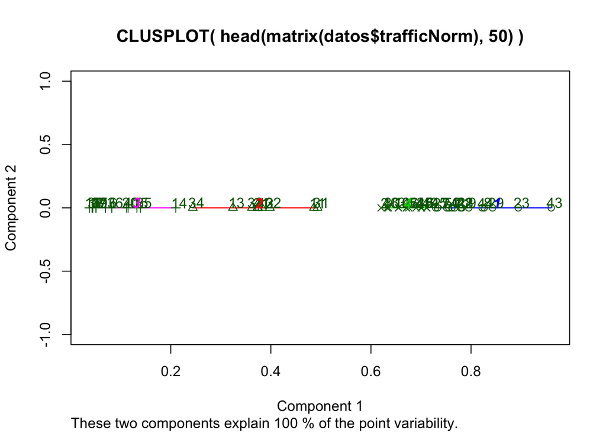

```r
clusplot(head(matrix(datos$trafficNorm),50), head(datos$nivelTrafico,50), color=TRUE, shade=TRUE, labels=2, lines=0)
```

Y vemos que “poco tráfico” es el grupo 3, “medio poco” el 2, “medio alto” el 4 y alto el 1. (Nótese que se fija la semilla para que los valores sean consistentes)

Lo traducimos al dataset para que quede más claro. Hacemos una doble manipulación de los datos para luego facilitar su visualización.

```r
datos$nivelTrafico <- gsub('3', 'Bajo', datos$nivelTrafico )
datos$nivelTrafico <- gsub('4', 'Medio alto', datos$nivelTrafico )
datos$nivelTrafico <- gsub('2', 'Medio bajo', datos$nivelTrafico )
datos$nivelTrafico <- gsub('1', 'Alto', datos$nivelTrafico )
datos$nivelTrafico <- as.factor(datos$nivelTrafico )
#Cambiamos el orden de los factores para que la visualización resute mejor posteriormente al estar ordenada lógicamente en lugar de alfabéticamente
datos$nivelTrafico = factor(datos$nivelTrafico, levels=c('Alto', 'Medio alto', 'Medio bajo', 'Bajo'))

#Aquí simplemente hago una copia que me puede servir después
datosPreparados<-datos
```

Una vez preparados los datos, vamos a crear un dataset solo con las columnas que nos interesan:

```r
datosArbol<-select (datos,holiday, anio, mes, franjaHoraria, lluvia, nieve, temperatura, nivelTrafico)
```

Y ahora vamos a generar el árbol teniendo en cuenta que la variable objetivo el el nivel de tráfico

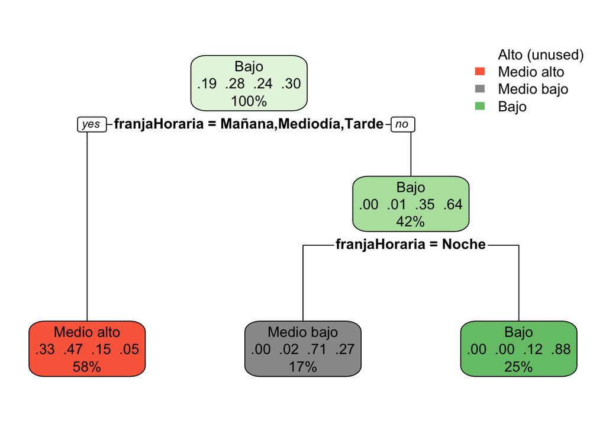

```r
arbolCompletoTrafico <- rpart(formula =nivelTrafico ~ ., data = datosArbol, method = "class")
rpart.plot(arbolCompletoTrafico)
```

De aquí observamos como principal conclusión que la principal variable que afecta (de hecho el árbol es la única que toma) para decidir sobre la cantidad de tráfico es la hora del día. Así:

- Si es madrugada, con un 88% de probabilidad el tráfico será bajo. En el 12% restante será medio-bajo.
- De noche en un 71% será medio-bajo y un 27% bajo (es posible que si moviéramos ligeramente las franjas horarias arbitrariamente elegidas se observara algún pequeño cambio).
- En “las horas de luz” el 80% del tiempo hay un tráfico alto o medio-alto.

Por curiosidad y a modo de ejercicio vamos a ver qué sucede si ignoramos las franjas horarias. Para ello, las eliminamos del árbol y ejecutamos el algoritmo.

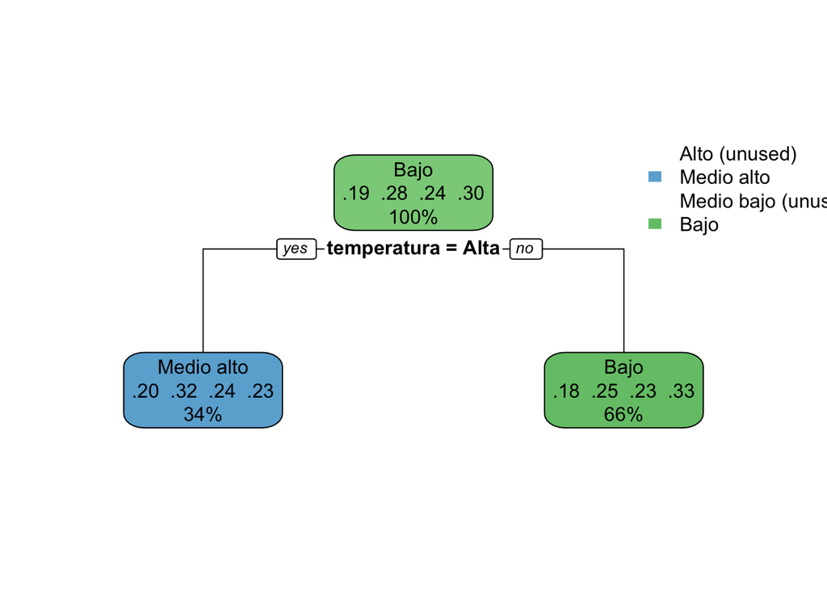

```r
datosArbolSinHora<-select (datos,holiday, anio, mes, lluvia, nieve, temperatura, nivelTrafico)

arbolCompletoTraficoSinHora <- rpart(formula =nivelTrafico ~ ., data = datosArbolSinHora, method = "class")
rpart.plot(arbolCompletoTraficoSinHora)
```

Lo que vemos es que cuando la temperatura no es alta el tráfico tiende a ser más bajo. En cierto modo, tiene su explicación: en las noches y madrugadas la temperatura baja; sin embargo, aún vemos valores relativamente altos para situaciones de tráfico alto. Esto se explica porque no todos los días tienen la misma temperatua; es decir, una noche de verano es más cálida que una tarde de invierno. Por tanto, la temperatura no es un buen indicador para el tráfico, mientras que sí lo son las franjas horarias.

Vamos a ver si logramos sacar reglas de asociación con el algoritmo a priori. Nótese que aquí el algoritmo será no supervisado, puesto que no vamos a tener en cuenta el valor de salida. De hecho vamos a tratar el tráfico como un parámetro más.

```r
library(arules)
reglasTrafico <- apriori(datosArbol, parameter = list(support = 0.01, confidence = 0.5))
```

```
## Apriori
##
## Parameter specification:
##  confidence minval smax arem  aval originalSupport maxtime support minlen
##         0.5    0.1    1 none FALSE            TRUE       5    0.01      1
##  maxlen target   ext
##      10  rules FALSE
##
## Algorithmic control:
##  filter tree heap memopt load sort verbose
##     0.1 TRUE TRUE  FALSE TRUE    2    TRUE
##
## Absolute minimum support count: 481
##
## set item appearances ...[0 item(s)] done [0.00s].
## set transactions ...[44 item(s), 48187 transaction(s)] done [0.03s].
## sorting and recoding items ... [31 item(s)] done [0.00s].
## creating transaction tree ... done [0.02s].
## checking subsets of size 1 2 3 4 5 6 7 done [0.01s].
## writing ... [9663 rule(s)] done [0.26s].
## creating S4 object  ... done [0.01s].
```

```r
#Ordenamos por confianza
inspect(head(sort(reglasTrafico, by = "confidence"), 5))
```

```
##     lhs         rhs               support    confidence lift     count
## [1] {mes=10} => {nieve=Sin nieve} 0.07207338 1          1.001309 3473
## [2] {mes=2}  => {nieve=Sin nieve} 0.07304875 1          1.001309 3520
## [3] {mes=11} => {nieve=Sin nieve} 0.07649366 1          1.001309 3686
## [4] {mes=6}  => {nieve=Sin nieve} 0.07827837 1          1.001309 3772
## [5] {mes=6}  => {holiday=None}    0.07827837 1          1.001268 3772
```

Ordenando por confianza obtenemos algunos datos curiosos aunque no demasiado relevantes. Por ejemplo vemos que nunca nieva en ciertos meses, o que e junio no hay festivos.

```r
#Ordenamos por soporte
inspect(head(sort(reglasTrafico, by = "support"), 5))
```

```
##     lhs                  rhs                 support   confidence lift
## [1] {}                => {holiday=None}      0.9987341 0.9987341  1.0000000
## [2] {}                => {nieve=Sin nieve}   0.9986926 0.9986926  1.0000000
## [3] {nieve=Sin nieve} => {holiday=None}      0.9974267 0.9987324  0.9999983
## [4] {holiday=None}    => {nieve=Sin nieve}   0.9974267 0.9986909  0.9999983
## [5] {}                => {lluvia=Sin lluvia} 0.9280719 0.9280719  1.0000000
##     count
## [1] 48126
## [2] 48124
## [3] 48063
## [4] 48063
## [5] 44721
```

Me llama la atención el primer dato. El 99,8% de los días no son festivos. Veo que, por algún motivo en el dataset cuando un día es festivo, tan solo una de las horas del día está catalogada como tal. Esto, evidentemente, adultera las conclusiones. Por tanto vamos a eliminar este parámetro y volvemos a generar las reglas. Como hasta ahora las vacaciones no habían sido un factor relevante, opto por dar por bueno todo lo obtenido hasta este punto.

```r
datosArbol<-select (datos, anio, mes, franjaHoraria, lluvia, nieve, temperatura, nivelTrafico)
reglasTrafico <- apriori(datosArbol, parameter = list(support = 0.01, confidence = 0.5))
```

```
## Apriori
##
## Parameter specification:
##  confidence minval smax arem  aval originalSupport maxtime support minlen
##         0.5    0.1    1 none FALSE            TRUE       5    0.01      1
##  maxlen target   ext
##      10  rules FALSE
##
## Algorithmic control:
##  filter tree heap memopt load sort verbose
##     0.1 TRUE TRUE  FALSE TRUE    2    TRUE
##
## Absolute minimum support count: 481
##
## set item appearances ...[0 item(s)] done [0.00s].
## set transactions ...[32 item(s), 48187 transaction(s)] done [0.03s].
## sorting and recoding items ... [30 item(s)] done [0.00s].
## creating transaction tree ... done [0.02s].
## checking subsets of size 1 2 3 4 5 6 done [0.00s].
## writing ... [3579 rule(s)] done [0.10s].
## creating S4 object  ... done [0.01s].
```

```r
inspect(head(sort(reglasTrafico, by = "support"), 15))
```

```
##      lhs                    rhs                   support confidence      lift count
## [1]  {}                  => {nieve=Sin nieve}   0.9986926  0.9986926 1.0000000 48124
## [2]  {}                  => {lluvia=Sin lluvia} 0.9280719  0.9280719 1.0000000 44721
## [3]  {lluvia=Sin lluvia} => {nieve=Sin nieve}   0.9268475  0.9986807 0.9999881 44662
## [4]  {nieve=Sin nieve}   => {lluvia=Sin lluvia} 0.9268475  0.9280608 0.9999881 44662
## [5]  {anio=[2017,2018]}  => {nieve=Sin nieve}   0.3849794  1.0000000 1.0013091 18551
## [6]  {anio=[2017,2018]}  => {lluvia=Sin lluvia} 0.3701828  0.9615654 1.0360894 17838
## [7]  {anio=[2017,2018],
##       lluvia=Sin lluvia} => {nieve=Sin nieve}   0.3701828  1.0000000 1.0013091 17838
## [8]  {anio=[2017,2018],
##       nieve=Sin nieve}   => {lluvia=Sin lluvia} 0.3701828  0.9615654 1.0360894 17838
## [9]  {temperatura=Alta}  => {nieve=Sin nieve}   0.3406313  1.0000000 1.0013091 16414
## [10] {anio=[2012,2015)}  => {nieve=Sin nieve}   0.3311682  1.0000000 1.0013091 15958
## [11] {temperatura=Media} => {nieve=Sin nieve}   0.3297985  1.0000000 1.0013091 15892
## [12] {temperatura=Baja}  => {nieve=Sin nieve}   0.3282628  0.9960330 0.9973369 15818
## [13] {temperatura=Baja}  => {lluvia=Sin lluvia} 0.3225351  0.9786537 1.0545021 15542
## [14] {lluvia=Sin lluvia,
##       temperatura=Baja}  => {nieve=Sin nieve}   0.3213107  0.9962038 0.9975080 15483
## [15] {nieve=Sin nieve,
##       temperatura=Baja}  => {lluvia=Sin lluvia} 0.3213107  0.9788216 1.0546830 15483
```

Vemos que es una zona donde llueve bastante poco. El 92.8% de las mediciones se hicieron sin lluvia y el 99.8 sin nieve.

Además vemos que en 2017 y 2018 no nevó nunca. También vemos (es lógico y no aporta conocimiento pero sí demuestra que el estudio es correcto), que si la temperatura es alta jamás nieva.

Vamos a intentar ver la relación entre las dos variables que más relación hemos visto que guardan y que son más interesantes desde el punto de vista del conocimiento: la franja horaria y el tráfico.

```r
datosArbol<-select (datos,  franjaHoraria,  nivelTrafico)
reglasTrafico <- apriori(datosArbol, parameter = list(support = 0.01, confidence = 0.5))
```

```
## Apriori
##
## Parameter specification:
##  confidence minval smax arem  aval originalSupport maxtime support minlen
##         0.5    0.1    1 none FALSE            TRUE       5    0.01      1
##  maxlen target   ext
##      10  rules FALSE
##
## Algorithmic control:
##  filter tree heap memopt load sort verbose
##     0.1 TRUE TRUE  FALSE TRUE    2    TRUE
##
## Absolute minimum support count: 481
##
## set item appearances ...[0 item(s)] done [0.00s].
## set transactions ...[9 item(s), 48187 transaction(s)] done [0.01s].
## sorting and recoding items ... [9 item(s)] done [0.00s].
## creating transaction tree ... done [0.02s].
## checking subsets of size 1 2 done [0.00s].
## writing ... [4 rule(s)] done [0.00s].
## creating S4 object  ... done [0.01s].
```

```r
inspect(head(sort(reglasTrafico, by = "support"), 5))
```

```
##     lhs                          rhs                       support
## [1] {franjaHoraria=Madrugada} => {nivelTrafico=Bajo}       0.22450038
## [2] {nivelTrafico=Bajo}       => {franjaHoraria=Madrugada} 0.22450038
## [3] {franjaHoraria=Noche}     => {nivelTrafico=Medio bajo} 0.11725154
## [4] {franjaHoraria=Mediodía}  => {nivelTrafico=Medio alto} 0.08925644
##     confidence lift     count
## [1] 0.8815189  2.972759 10818
## [2] 0.7570859  2.972759 10818
## [3] 0.7066917  2.985565  5650
## [4] 0.7378624  2.672131  4301
```

Aunque con un nivel de confianza menor, aquí obtenemos reglas más interesantes: como habíamos visto anteriormente, de madrugada el 88% de las mediciones dan tráfico bajo. Por otro lado, de todas las mediciones que vemos de tráfico bajo el 75% son de madrugada (con lo que vemos cierta correlación). Podemos ver otras normas en la lista.

**Algoritmos no supervisados**

Vamos ahora a utilizar un algoritmo no supervisado como el kmeans para el conjunto de datos.

Volvemos al dataset original datosCopia. Vamos a quedarnos con los valores de temperatura, lluvia, nieve, porcentaje de lluvia y hora.

Sabemos del análisis que la hora es el factor más relevante en este caso para la variable del tráfico. Vamos a intentar hacer un análisis diferente: tratar de estimar el mes del año en función de las agrupaciones. Es algo bastante difícil y que cabría esperar que no funcionara, puesto que a diferentes horas del día podría cambiar la temperatura completamente (digamos que a las 12 de la noche en verano hace más calor que a las 12 de la mañana en invierno).

Vamos, por tanto, a tomar el subconjunto de las medidas realizadas a una hora (pongamos las 14h) y vamos a analizar qué sucede.

```r
datosAnalisis<-select (datosCopia, rain_1h, snow_1h, clouds_all, temp, hora)
datosAnalisis<-filter(datosAnalisis, hora==14)
summary(datosAnalisis)
```

```
##     rain_1h           snow_1h            clouds_all          temp
##  Min.   :0.00000   Min.   :0.0000000   Min.   :  0.00   Min.   :-25.35
##  1st Qu.:0.00000   1st Qu.:0.0000000   1st Qu.: 20.00   1st Qu.:  1.00
##  Median :0.00000   Median :0.0000000   Median : 75.00   Median : 13.13
##  Mean   :0.09878   Mean   :0.0005383   Mean   : 54.61   Mean   : 11.10
##  3rd Qu.:0.00000   3rd Qu.:0.0000000   3rd Qu.: 90.00   3rd Qu.: 22.73
##  Max.   :7.02000   Max.   :0.3200000   Max.   :100.00   Max.   : 34.54
##       hora
##  Min.   :14
##  1st Qu.:14
##  Median :14
##  Mean   :14
##  3rd Qu.:14
##  Max.   :14
```

Vamos a ejecutar el kmeans para este dataset. Primero, como buena práctica del kmeans, vamos a normalizar los valores.

```r
normalizar <- function(x){(x-min(x))/(max(x)-min(x))}
#Normalizo los valores de cada columna.
for (i in c(1,2,3,4))
{
datosAnalisis[i] <- normalizar(datosAnalisis[i])
}
```

Una vez que tenemos los datos normalizados vamos a ver las agrupaciones que obtenemos.

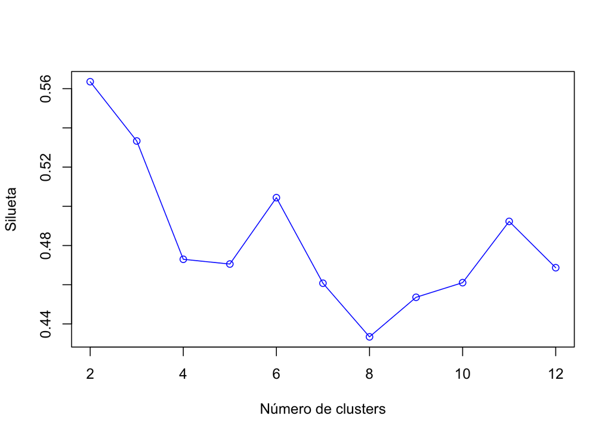

```r
matDist <- daisy(datosAnalisis)
resultadosDaisy <- rep(0, 12)
resultadosCodo <- rep(0, 12)
for (i in c(2,3,4,5,6,7,8,9,10,11,12))
{
  set.seed(1)
  ajuste           <- kmeans(datosAnalisis, i)
  y_cluster     <- ajuste$cluster
  resultadosCodo[i] <- ajuste$tot.withinss
  silueta            <- silhouette(y_cluster, matDist)
  resultadosDaisy[i] <- mean(silueta[,3])

}
plot(2:12,resultadosDaisy[2:12],type="o",col="blue",xlab="Número de clusters",ylab="Silueta")
```

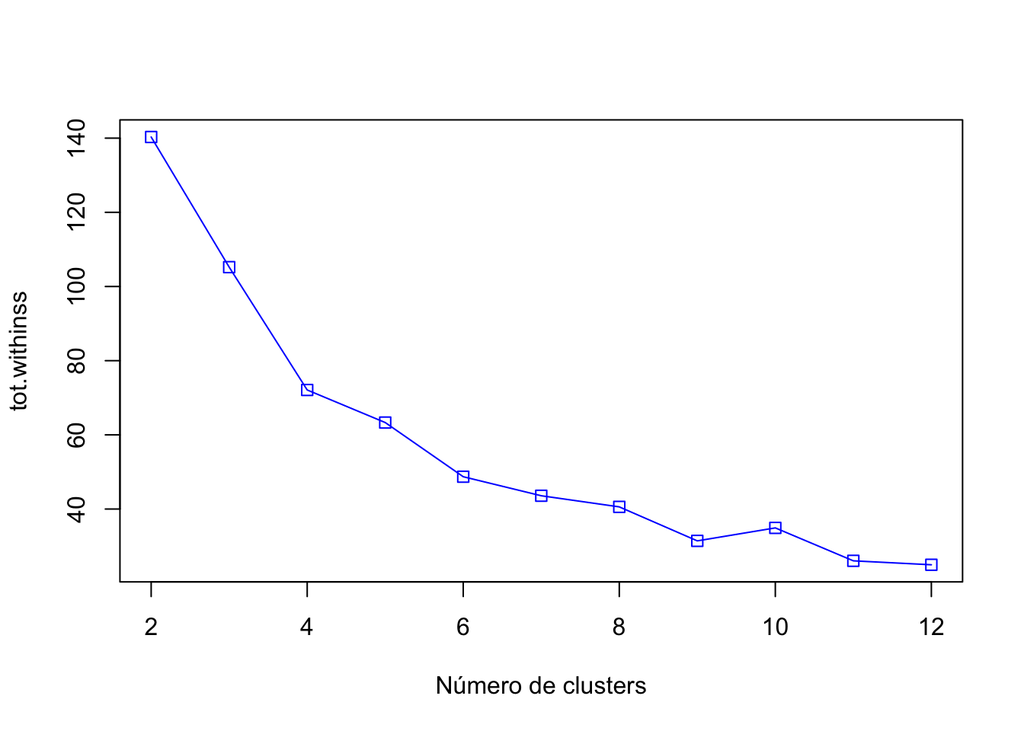

```r
plot(2:12,resultadosCodo[2:12],type="o",col="blue",pch=0,xlab="Número de clusters",ylab="tot.withinss")
```

Vemos que para 6 conjuntos obtenemos unos resultados “prometedores” tanto en el codo como en la silueta. Parece arriesgado calificar las condiciones climatológicas en 6 grupos pero vamos a intentarlo.

```r
datosCopiaFiltrados<-select (datosCopia, rain_1h, snow_1h, clouds_all, temp, hora, mes)
datosCopiaFiltrados<-filter(datosCopiaFiltrados, hora==14)
seisClusters <- kmeans(datosAnalisis, 6)
table(seisClusters$cluster,datosCopiaFiltrados$mes)
```

```
##
##       1   2   3   4   5   6   7   8   9  10  11  12
##   1  92  80  73  62  17   0   0   0   1  24  62 109
##   2   0   3   8  28  95  83  74  76  71  54  23   4
##   3  40  42  39  20   1   0   0   0   0   6  22  32
##   4   0   3   5  31  51  43  62  62  56  37  21   0
##   5  31  18   9   6   0   0   0   0   0   2  26  48
##   6   0   1   2  13  28  29  60  39  25  17   3   0
```

Vamos a tratar de entender esta tabla: hay que entender que tenemos 6 grupos para 12 meses.

Seguramente “el acierto” con respecto al mes no sea exacto, pero creo que da una buena idea de cómo el algoritmo ha hecho las agrupaciones.

Vamos a ver cómo funcionaría con agrupamiento jerárquico (hierarchical clustering)

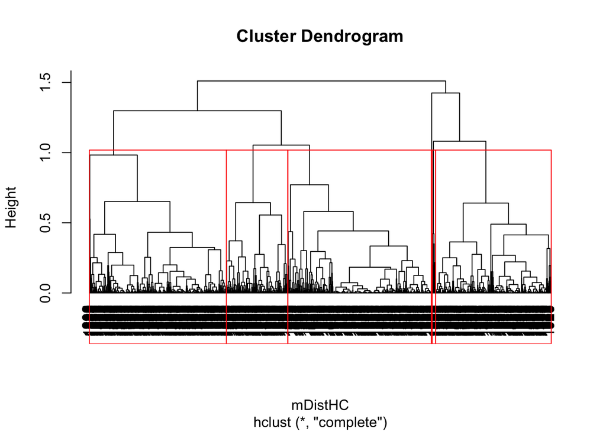

```r
#Calculo la matriz distancia

mDistHC <- dist (as.matrix(datosAnalisis))
#Aplico el algoritmo
ajusteHC <- hclust (mDistHC)
#Muestro el diagrama
plot (ajusteHC, hang=-1)

#Intento mostrar en bordes rojos los  grupos
rect.hclust(ajusteHC, k=6, border="red") # pintamos el gráfico
```

```r
#Vemos el resultado
groups<-cutree(ajusteHC, k=6)
groups
```

[output not shown]

[output cut: 39 more lines]

Aquí observamos que la partición es diferente. Mientras que en la agrupación por kmeans el número de elementos en cada grupo era mucho más homogéneo, en el agrupamiento jerárquico no.

Por ejemplo, el grupo 6 (que es muy ecaso) corresponde a los momentos de máxima nieve y el 5 a los de lluvia.

El grupo 1 son días cálidos y no nublados, el 2 hace referencia a días templados y nubosos, el 3 son mayoritariamente días cálidos pero con nubosidad, y el 4 a días frescos pero despejados.

**Algoritmos supervisados**

A continuación vamos a pasar a los métodos supervisados. Vamos a retomar la idea de que la variable objetivo es el tráfico y vamos a generar un modelo que vamos a analizar.

Para separar los conjuntos de entrenamiento y prueba vamos a hacer lo siguiente: vamos a ver cómo de bueno habría sido el modelo de las mediciones de 2012 y 2016 para predcir lo ocurrido en 2017 y 2018.

```r
datosKNN<-select(datos, temp, rain_1h, snow_1h, anio, mes, hora, nivelTrafico)
datosKNN$mes<-as.numeric(datosKNN$mes)
for (i in c(1,2,3))
{
datosKNN[i] <- normalizar(datosKNN[i])
}
datosTrain <- filter(datosKNN, anio<2017)
datosTest <- filter(datosKNN, anio>=2017)
```

Una vez separados los conjuntos nos disponemos a ejecutar el algoritmo:

```r
vecinos <- knn(datosTrain[1:6],datosTest[1:6],cl=datosTrain$nivelTrafico, k=1)
error <- mean(vecinos!=datosTest$nivelTrafico)
confusionMatrix(vecinos,datosTest$nivelTrafico)
```

```
## Confusion Matrix and Statistics
##
##             Reference
## Prediction   Alto Medio alto Medio bajo Bajo
##   Alto       2015        887        299  240
##   Medio alto 1020       3746        541   94
##   Medio bajo  256        642       2899  568
##   Bajo        217         69        572 4486
##
## Overall Statistics
##
##                Accuracy : 0.7086
##                  95% CI : (0.702, 0.7152)
##     No Information Rate : 0.2904
##     P-Value [Acc > NIR] : < 2.2e-16
##
##                   Kappa : 0.6077
##
##  Mcnemar's Test P-Value : 0.0002012
##
## Statistics by Class:
##
##                      Class: Alto Class: Medio alto Class: Medio bajo
## Sensitivity               0.5744            0.7010            0.6725
## Specificity               0.9052            0.8747            0.8971
## Pos Pred Value            0.5856            0.6936            0.6641
## Neg Pred Value            0.9012            0.8785            0.9005
## Prevalence                0.1891            0.2881            0.2324
## Detection Rate            0.1086            0.2019            0.1563
## Detection Prevalence      0.1855            0.2911            0.2353
## Balanced Accuracy         0.7398            0.7878            0.7848
##                      Class: Bajo
## Sensitivity               0.8326
## Specificity               0.9348
## Pos Pred Value            0.8394
## Neg Pred Value            0.9317
## Prevalence                0.2904
## Detection Rate            0.2418
## Detection Prevalence      0.2881
## Balanced Accuracy         0.8837
```

Vemos que los valores no son demasiado buenos. Un 70% no es lo deseado. Seguramente se debe a que sabemos que hay datos que generan “ruido”, siendo la hora el valor claramente determinante. Vamos a hacer el mismo ejercicio pero solo con la hora y el mes.

```r
datosKNN<-select(datosKNN, anio, mes, hora, nivelTrafico)
datosKNN$mes<-as.numeric(datosKNN$mes)
datosTrain <- filter(datosKNN, anio<2017)
datosTest <- filter(datosKNN, anio>=2017)

vecinos <- knn(datosTrain[2:3],datosTest[2:3],cl=datosTrain$nivelTrafico, k=1)
error <- mean(vecinos!=datosTest$nivelTrafico)
confusionMatrix(vecinos,datosTest$nivelTrafico)
```

```
## Confusion Matrix and Statistics
##
##             Reference
## Prediction   Alto Medio alto Medio bajo Bajo
##   Alto       2986       1019        422  410
##   Medio alto  522       4079        535   25
##   Medio bajo    0        241       3051  469
##   Bajo          0          5        303 4484
##
## Overall Statistics
##
##                Accuracy : 0.787
##                  95% CI : (0.7811, 0.7929)
##     No Information Rate : 0.2904
##     P-Value [Acc > NIR] : < 2.2e-16
##
##                   Kappa : 0.7154
##
##  Mcnemar's Test P-Value : < 2.2e-16
##
## Statistics by Class:
##
##                      Class: Alto Class: Medio alto Class: Medio bajo
## Sensitivity               0.8512            0.7633            0.7077
## Specificity               0.8770            0.9181            0.9501
## Pos Pred Value            0.6173            0.7904            0.8112
## Neg Pred Value            0.9619            0.9055            0.9148
## Prevalence                0.1891            0.2881            0.2324
## Detection Rate            0.1610            0.2199            0.1645
## Detection Prevalence      0.2607            0.2782            0.2027
## Balanced Accuracy         0.8641            0.8407            0.8289
##                      Class: Bajo
## Sensitivity               0.8322
## Specificity               0.9766
## Pos Pred Value            0.9357
## Neg Pred Value            0.9343
## Prevalence                0.2904
## Detection Rate            0.2417
## Detection Prevalence      0.2583
## Balanced Accuracy         0.9044
```

Vemos que limitando a la hora y el mes obtenemos casi un 79% de acierto, lo que mejora considerablemente el caso anterior.

**PCA y comparativa**

Por último, vamos a aplicar PCA al juego de datos de que disponemos y vamos a realizar un estudio similar.

Para ello vamos a partir de los datos de los mismos datos que antes y vamos a aplicar PCA.

```r
#Obtenemos el conjunto de valores sobre el que aplicar PCA
datosPCA<-select(datos, temp, rain_1h, snow_1h, anio, mes, hora, nivelTrafico)
datosPCA$mes<-as.numeric(datosPCA$mes)
datosTrainPCA <- filter(datosPCA, anio<2017)
datosTestPCA <- filter(datosPCA, anio>=2017)
#Quitamos el valor de clase de los conjuntos de entrenamiento.
pca.train <- subset(datosTrainPCA, select = -nivelTrafico)
pca.test<- subset(datosTestPCA, select = -nivelTrafico)
```

Ahora aplicamos PCA sobre el conjunto de entrenamiento

```r
prin_comp <- prcomp(pca.train, cor = TRUE, scale. = T)
summary(prin_comp)
```

```
## Importance of components:
##                           PC1    PC2    PC3    PC4    PC5    PC6
## Standard deviation     1.1340 1.0243 1.0079 1.0024 0.9834 0.8227
## Proportion of Variance 0.2143 0.1749 0.1693 0.1675 0.1612 0.1128
## Cumulative Proportion  0.2143 0.3892 0.5585 0.7260 0.8872 1.0000
```

Nos quedamos con los 4 primeros componentes principales, que son los que tienen un valor superior a 1 en la desviación estándar.

```r
train.data <- data.frame(nivelTrafico = datosTrainPCA$nivelTrafico, prin_comp$x)
train.data <- train.data[,1:5]
model <- rpart(nivelTrafico ~ .,data = train.data, method = "class")
model
```

```
## n= 29636
##
## node), split, n, loss, yval, (yprob)
##       * denotes terminal node
##
##  1) root 29636 20735 Bajo (0.191591308 0.268659738 0.239404778 0.300344176)
##    2) PC4>=-0.1951 19552 12906 Medio alto (0.229644026 0.339914075 0.306106792 0.124335106)
##      4) PC4< 0.6189845 15905  9671 Medio alto (0.272807293 0.391952216 0.232631248 0.102609242)
##        8) PC2>=-1.909575 14713  8736 Medio alto (0.282607218 0.406239380 0.212261266 0.098892136)
##         16) PC3>=-0.6938463 11497  6532 Medio alto (0.305123076 0.431851787 0.167348004 0.095677133) *
##         17) PC3< -0.6938463 3216  2017 Medio bajo (0.202114428 0.314676617 0.372823383 0.110385572)
##           34) PC2>=0.23061 1753   891 Medio alto (0.342270394 0.491728465 0.160867085 0.005134056) *
##           35) PC2< 0.23061 1463   546 Medio bajo (0.034176350 0.102529050 0.626794258 0.236500342) *
##        9) PC2< -1.909575 1192   615 Medio bajo (0.151845638 0.215604027 0.484060403 0.148489933) *
##      5) PC4>=0.6189845 3647  1362 Medio bajo (0.041403894 0.112969564 0.626542364 0.219084179) *
##    3) PC4< -0.1951 10084  3614 Bajo (0.117810393 0.130503768 0.110075367 0.641610472)
##      6) PC2< 0.160839 4600  2470 Bajo (0.164782609 0.224782609 0.147391304 0.463043478)
##       12) PC3< 0.7325974 1606   825 Medio alto (0.230386052 0.486301370 0.197384807 0.085927771) *
##       13) PC3>=0.7325974 2994  1002 Bajo (0.129592518 0.084502338 0.120574482 0.665330661) *
##      7) PC2>=0.160839 5484  1144 Bajo (0.078409920 0.051422319 0.078774617 0.791393144) *
```

Ahora vamos a trabajar con los datos de TEST

```r
test.data <- predict(prin_comp, newdata = pca.test)
test.data <- as.data.frame(test.data)
test.data <- test.data[,1:4]
```

Y realizamos la predicción

```r
prediction <- predict(model, test.data, type = "class")
f<-data.frame(datosTestPCA,predi=prediction)

fit<-sqldf("select count(*) from f where nivelTrafico=predi")/nrow(f)
fit
```

```
##    count(*)
## 1 0.5316155
```

Vemos que el resultado es inferior al obtenido con anterioridad.

Creo que esto tiene bastante sentido en nuestro dataset. Hay que tener en cuenta que, como hemos visto durante el desarrollo del ejercicio, en nuestro juego de datos, la hora del día es el valor decisivo. Si empezamos a dar peso a otros parémetros sin ponderar la hora, el porcentaje de acierto decae. En todo caso, un 53% de acierto no es un porcentaje horroroso, aunque sí inferior al que hemos conseguido antes del 79% ponderando la hora.

En este dataset no parecía buena idea haer un estudio PCA sino más bien potenciar la hora del día como factor diferencial.